# Genetic Dependency Detection

Martin Brand

März 22, 2023

We import the libraries.

```r
library(tidyverse)
library(ggplot2)
library(ggrepel)
library(matrixTests)
library(dplyr)
library(cowplot)
library(limma)
library(gridExtra)
```

# Analyzed Genes and Target

We define the genes for classification, the expected target gene and the classification criteria.

```r
gene1 <- "SNRPD1"
gene2 <- "SNRPD2"
target.genes <- c("FUBP1","SF1","U2AF1","U2AF2","SNRPB","SNRPD1","SNRPD2",
                  "SNRPD3","SNRPE","SNRPF","SNRPG","PUF60","SMNDC1",
                  "DNAJC8","RBM17","CHERP","U2SURP","DHX15","DDX46","CELF6",
                  "PCBP1")
# possible methods: "del.vs.non.del", "del.vs.non.mut","mut.vs.non.mut"
classification.method <- "mut.vs.non.mut"
```

In this analysis, the genes used for classification are SNRPD1 and SNRPD2. The expected target gene is FUBP1, SF1, U2AF1, U2AF2, SNRPB, SNRPD1, SNRPD2, SNRPD3, SNRPE, SNRPF, SNRPG, PUF60, SMNDC1, DNAJC8, RBM17, CHERP, U2SURP, DHX15, DDX46, CELF6, PCBP1.

# Data Preprocessing

We define the directory for the data and helper functions.

```r
data.dir <-
  "C:/Users/Martin/Documents/Master/Thesis/genetic_dependency_detection/data/"
```

We load the dataset that contains CCLE IDs and corresponding DepMap IDs for the cell lines ([DepMapIDs](https://depmap.org/portal/download/all/?releasename=DepMap+Public+18Q3&filename=DepMap-2018q3-celllines.csv)), the dataset that contains the mutation information of the cell lines ([CCLE dataset](https://depmap.org/portal/download/all/?releasename=DepMap+Public+19Q2&filename=CCLE_mutations.csv)) and the datasets that contains the dependency scores from the projects Achilles and DRIVE ([DepMap datasets](https://figshare.com/articles/dataset/DepMap_Datasets_for_WRN_manuscript/7712756/1)).

```r
cancer.names <- read.csv(paste0(data.dir, "DepMap-2018q3-celllines.csv"))
cancer.names <- cancer.names[,c(1,2)]
colnames(cancer.names) <- c("DepMap_ID","CCLE_ID")

CCLE.mut <- read.csv(paste0(data.dir, "CCLE_mutations.csv"))
CCLE.mut <- CCLE.mut[,c(1,8,16,20)]

dep.scores <- read_rds(file.path(data.dir, 'DepMap_18Q4_data.rds'))

dep.scores.DRIVE <- as.data.frame(dep.scores[["DRIVE"]])
dep.scores.DRIVE$CCLE_ID <- rownames(dep.scores.DRIVE)
rownames(dep.scores.DRIVE) <- NULL
dep.scores.DRIVE <- dep.scores.DRIVE %>% select(CCLE_ID, everything())

dep.scores.Achilles <- as.data.frame(dep.scores[["CRISPR"]])
dep.scores.Achilles$CCLE_ID <- rownames(dep.scores.Achilles)
rownames(dep.scores.Achilles) <- NULL
dep.scores.Achilles <- dep.scores.Achilles %>% select(CCLE_ID,everything())

# remove unnecessary objects
rm(dep.scores)

# save important objects
saveRDS(cancer.names,paste0(data.dir,"cancer.names.rds"))
saveRDS(CCLE.mut,paste0(data.dir,"CCLE.mut.rds"))
saveRDS(dep.scores.DRIVE,paste0(data.dir,"dep.scores.DRIVE.rds"))
saveRDS(dep.scores.Achilles,paste0(data.dir,"dep.scores.Achilles.rds"))
```

```r
# load important objects
cancer.names <- readRDS(paste0(data.dir,"cancer.names.rds"))
CCLE.mut <- readRDS(paste0(data.dir,"CCLE.mut.rds"))
dep.scores.DRIVE <- readRDS(paste0(data.dir,"dep.scores.DRIVE.rds"))
dep.scores.Achilles <- readRDS(paste0(data.dir,"dep.scores.Achilles.rds"))
```

We load the helper functions.

```r
# load helper functions
source("helper_functions/create.mutation.counts.plot.R")
source("helper_functions/create.mutation.counts.plot.mark.R")
source("helper_functions/create.classification.table.del.vs.non.del.R")
source("helper_functions/create.classification.table.mut.vs.non.mut.R")
source("helper_functions/create.classification.table.del.vs.non.mut.R")
source("helper_functions/merge.class.tables.R")
source("helper_functions/create_barcharts_classifications.R")
source("helper_functions/plot.mean.diffs.R")
source("helper_functions/calc.mean.diffs.and.p.values.R")
source("helper_functions/create_volcano_plot.R")
source("helper_functions/create.significant.genes.table.R")
```

# Data Exploration

## Mutation Counts

To find potential genes for classification, we plot the distribution of mutation numbers in the overlapping genes of the CCLE dataset and the datasets DRIVE and Achilles.

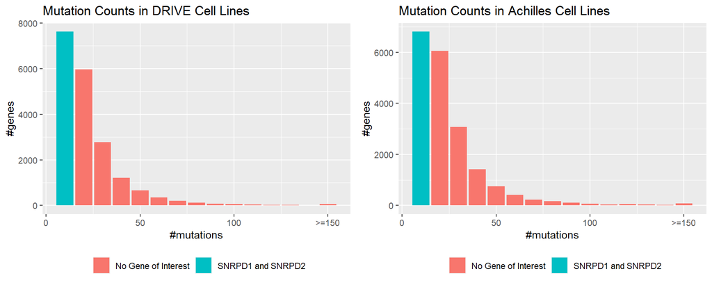

```r
mutation.plot.DRIVE <- create.mutation.counts.plot.mark("DRIVE",dep.scores.DRIVE,
                                                   cancer.names,CCLE.mut)

mutation.plot.Achilles <- create.mutation.counts.plot.mark("Achilles",
                                                      dep.scores.Achilles,
                                                      cancer.names,CCLE.mut)

grid.arrange(mutation.plot.DRIVE,mutation.plot.Achilles,ncol=2)
```

```r
rm(mutation.plot.DRIVE,mutation.plot.Achilles)
```

## Classification Tables for SNRPD1 and SNRPD2

We create classification tables that show us for each cell line whether the selected genes are deleteriously mutated or not. Therefore we create one table where we check whether SNRPD1 is deleteriously mutated, another table where we do the same for SNRPD2 and a third table where we check whether at least one of SNRPD1 and SNRPD2 is deleteriously mutated.

```r
create.classification.table <- switch(classification.method,
                "del.vs.non.del" = create.classification.table.del.vs.non.del,
                "del.vs.non.mut" = create.classification.table.del.vs.non.mut,
                "mut.vs.non.mut" = create.classification.table.mut.vs.non.mut)

class.table.gene1 <- create.classification.table(
                                                CCLE.mut, cancer.names,
                                                gene1, dep.scores.DRIVE,
                                                dep.scores.Achilles)
class.table.gene2 <- create.classification.table(
                                                CCLE.mut, cancer.names,
                                                gene2, dep.scores.DRIVE,
                                                dep.scores.Achilles)

# merge tables
class.table.comb.DRIVE <- merge.class.tables(class.table.gene1$DRIVE,
                                             class.table.gene2$DRIVE)

class.table.comb.Achilles <- merge.class.tables(class.table.gene1$Achilles,
                                             class.table.gene2$Achilles)

head(class.table.comb.DRIVE)
```

```
##                                  CCLE_ID isDeleterious
## 1                     127399_SOFT_TISSUE         FALSE
## 2          1321N1_CENTRAL_NERVOUS_SYSTEM         FALSE
## 3                        2313287_STOMACH         FALSE
## 4 697_HAEMATOPOIETIC_AND_LYMPHOID_TISSUE         FALSE
## 5                            769P_KIDNEY         FALSE
## 6                            786O_KIDNEY         FALSE
```

```r
rm(CCLE.mut,cancer.names)
```

## Classifications for SNRPD1

To check whether the samples sizes regarding SNRPD1 for the following statistical tests are sufficient, we plot the number of cell lines for both samples.

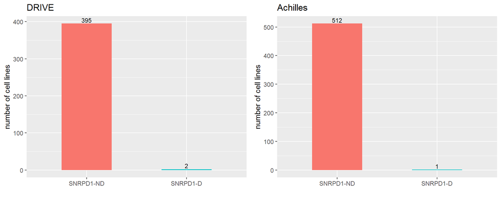

```r
barcharts.gene1 <- create_barcharts_classifications(class.table.gene1$DRIVE,
                                              class.table.gene1$Achilles,
                                              gene1)
plot_grid(barcharts.gene1$DRIVE, barcharts.gene1$Achilles)
```

```r
rm(barcharts.gene1)
```

## Classifications for SNRPD2

We repeat the plots for SNRPD2.

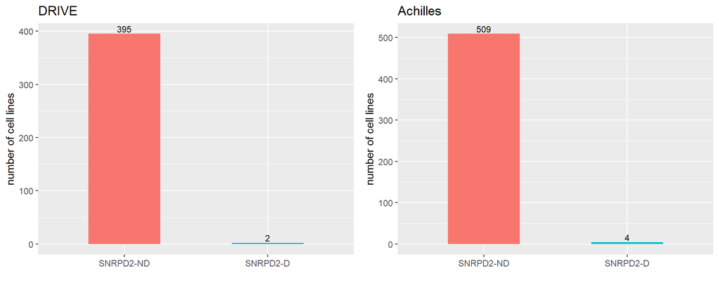

```r
barcharts.gene2 <- create_barcharts_classifications(class.table.gene2$DRIVE,
                                              class.table.gene2$Achilles,
                                              gene2)
plot_grid(barcharts.gene2$DRIVE, barcharts.gene2$Achilles)
```

```r
rm(barcharts.gene2)
```

## Classifications for SNRPD1and SNRPD2

We repeat the plots for SNRPD1and SNRPD2.

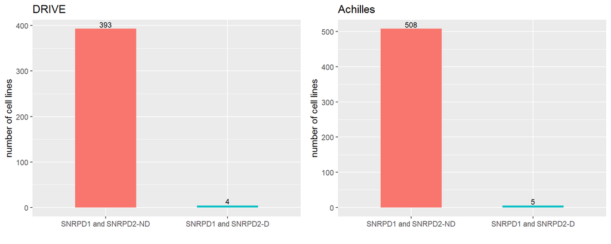

```r
barcharts.comb.genes <- create_barcharts_classifications(class.table.comb.DRIVE,
                                              class.table.comb.Achilles,
                                              paste(gene1,"and",gene2))
plot_grid(barcharts.comb.genes$DRIVE, barcharts.comb.genes$Achilles)
```

```r
rm(barcharts.comb.genes)
```

# Data Analysis SNRPD1

In order to detect differences between both samples, we compare them for each gene in the datasets DRIVE and Achilles. The workflow was published by [Chan et al., 2019](https://www.nature.com/articles/s41586-019-1102-x).

## Mean Differences

To test whether the two groups respond differently to the knock out or the knock down of a specific gene, we calculate the mean differences between the two groups for each gene.

```r
test.results.gene1 <- calc.mean.diffs.and.p.values(dep.scores.DRIVE,
                                           dep.scores.Achilles,
                                           class.table.gene1$DRIVE,
                                           class.table.gene1$Achilles)
```

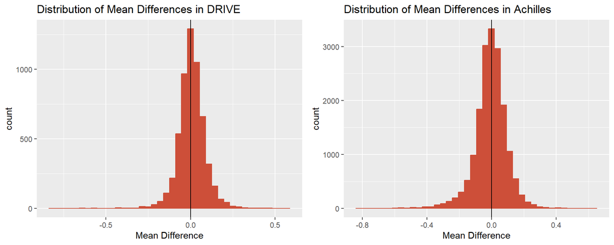

```r
plots <- plot.mean.diffs(test.results.gene1)
grid.arrange(plots$DRIVE,plots$Achilles,ncol=2)
```

```r
rm(class.table.gene1,plots)
```

## Welch Test

The Welch t-test checks whether the means of two samples are identical. The prerequisite is that both samples are normally distributed, which we have not yet ensured.

[figure not shown]

```r
plot.welch.DRIVE.gene1 <- create_volcano_plot(test.results.gene1,"DRIVE",
                                              "welch",target.genes,
                                              show_sign_line=T)

plot.welch.Achilles.gene1 <- create_volcano_plot(test.results.gene1,"Achilles",
                                                "welch",target.genes)

grid.arrange(plot.welch.DRIVE.gene1,plot.welch.Achilles.gene1,ncol=2)
```

```r
rm(plot.welch.DRIVE.gene1,plot.welch.Achilles.gene1)
```

To discover new potential dependencies, the table shows all significant genes.

```r
significant.genes.table.DRIVE.gene1 <- create.significant.genes.table(
  test.results.gene1,"DRIVE","welch")
significant.genes.table.Achilles.gene1 <- create.significant.genes.table(
  test.results.gene1,"Achilles","welch")
significant.genes.table.DRIVE.gene1
```

```
##                                  gene      p_value        p_adj        log
## 2402                             HCN1 7.222002e-80 4.042154e-76 173.599689
## 5202                             IER3 7.582826e-39 2.122054e-35  79.838094
## 5090                             LGR5 2.469621e-37 4.607491e-34  76.760210
## 3860                           PCDH10 1.913845e-34 2.677947e-31  70.395087
## 3475                             DET1 4.580332e-33 5.127223e-30  67.442989
## 2178                             RPA4 2.563518e-31 2.391335e-28  63.600531
## 4881                            DDX59 3.562331e-31 2.848338e-28  63.425647
## 67              EEF1E1-BLOC1S5&EEF1E1 8.191431e-30 4.829522e-27  60.595050
## 3616                          PRKAR1A 7.407261e-30 4.829522e-27  60.595050
## 4181                          DCLRE1C 8.628769e-30 4.829522e-27  60.595050
## 3624                            OGDHL 1.909011e-28 9.713393e-26  57.593707
## 1685                             FZD2 3.740554e-28 1.744657e-25  57.008070
## 3369                             POLG 6.804246e-27 2.929489e-24  54.187214
## 4630                         CACNA2D1 2.455627e-26 9.817244e-24  52.977902
```

[output cut: 309 more lines]

```r
significant.genes.table.Achilles.gene1
```

[output not shown]

[output cut: 17580 more lines]

[output not shown]

```r
rm(significant.genes.table.DRIVE.gene1,significant.genes.table.Achilles.gene1)
```

## Wilcoxon Test

The Wilcoxon test checks whether, for randomly selected values X and Y from two samples, the probability of X being greater than Y is equal to the probability of Y being greater than X. The prerequisite is that the data are ordinary, which is fulfilled here.

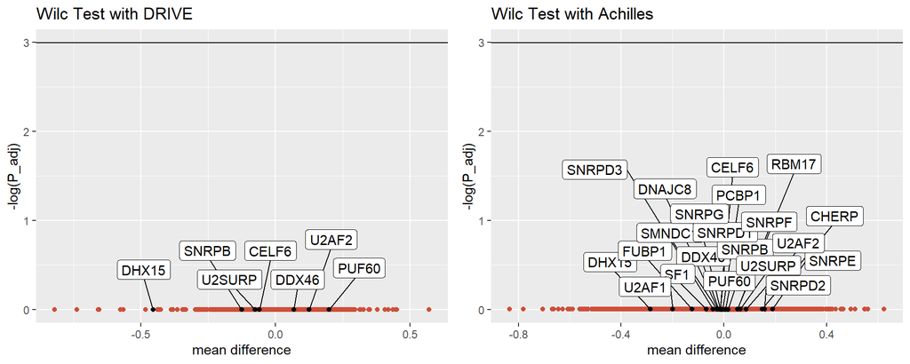

```r
plot.wilc.DRIVE.gene1 <- create_volcano_plot(test.results.gene1,"DRIVE","wilc",
                                       target.genes, show_sign_line=T)

plot.wilc.Achilles.gene1 <- create_volcano_plot(test.results.gene1,"Achilles",
                                                "wilc",target.genes)

grid.arrange(plot.wilc.DRIVE.gene1,plot.wilc.Achilles.gene1,ncol=2)
```

```r
rm(plot.wilc.DRIVE.gene1,plot.wilc.Achilles.gene1)
```

```r
significant.genes.table.DRIVE.gene1 <- create.significant.genes.table(
  test.results.gene1,"DRIVE","wilc")
significant.genes.table.Achilles.gene1 <- create.significant.genes.table(
  test.results.gene1,"Achilles","wilc")
significant.genes.table.DRIVE.gene1
```

```
## [1] gene    p_value p_adj   log
## <0 rows> (or 0-length row.names)
```

```r
significant.genes.table.Achilles.gene1
```

```
## [1] gene    p_value p_adj   log
## <0 rows> (or 0-length row.names)
```

```r
rm(significant.genes.table.DRIVE.gene1,significant.genes.table.Achilles.gene1)
```

## Bayes Test

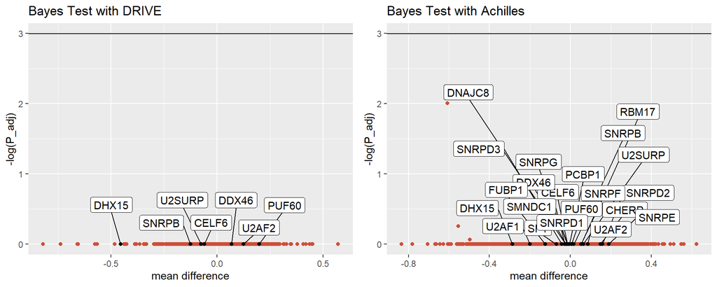

```r
plot.bayes.DRIVE.gene1 <- create_volcano_plot(test.results.gene1,"DRIVE","bayes",
                                       target.genes)

plot.bayes.Achilles.gene1 <- create_volcano_plot(test.results.gene1,"Achilles",
                                                "bayes",target.genes)

grid.arrange(plot.bayes.DRIVE.gene1,plot.bayes.Achilles.gene1,ncol=2)
```

```r
rm(plot.bayes.DRIVE.gene1,plot.bayes.Achilles.gene1)
```

```r
significant.genes.table.DRIVE.gene1 <- create.significant.genes.table(
  test.results.gene1,"DRIVE","bayes")
significant.genes.table.Achilles.gene1 <- create.significant.genes.table(
  test.results.gene1,"Achilles","bayes")
significant.genes.table.DRIVE.gene1
```

```
## [1] gene  p_adj log
## <0 rows> (or 0-length row.names)
```

```r
significant.genes.table.Achilles.gene1
```

```
## [1] gene  p_adj log
## <0 rows> (or 0-length row.names)
```

```r
rm(significant.genes.table.DRIVE.gene1,significant.genes.table.Achilles.gene1,
   test.results.gene1)
```

# Data Analysis SNRPD2

We do the same for SNRPD2.

## Mean Differences

```r
test.results.gene2 <- calc.mean.diffs.and.p.values(dep.scores.DRIVE,
                                           dep.scores.Achilles,
                                           class.table.gene2$DRIVE,
                                           class.table.gene2$Achilles)
```

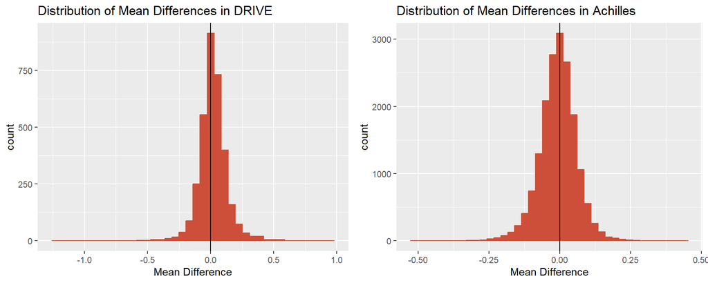

```r
plots <- plot.mean.diffs(test.results.gene2)
grid.arrange(plots$DRIVE,plots$Achilles,ncol=2)
```

```r
rm(class.table.gene2,plots)
```

## Welch Test

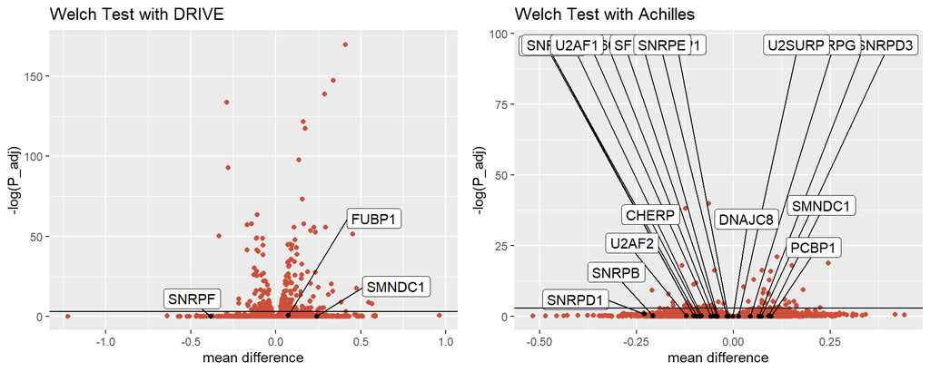

```r
plot.welch.DRIVE.gene2 <- create_volcano_plot(test.results.gene2,"DRIVE",
                                              "welch",target.genes,
                                              show_sign_line=T)

plot.welch.Achilles.gene2 <- create_volcano_plot(test.results.gene2,"Achilles",
                                                "welch",target.genes)

grid.arrange(plot.welch.DRIVE.gene2,plot.welch.Achilles.gene2,ncol=2)
```

```r
rm(plot.welch.DRIVE.gene2,plot.welch.Achilles.gene2)
```

```r
significant.genes.table.DRIVE.gene2 <- create.significant.genes.table(
  test.results.gene2,"DRIVE","welch")
significant.genes.table.Achilles.gene2 <- create.significant.genes.table(
  test.results.gene2,"Achilles","welch")
significant.genes.table.DRIVE.gene2
```

```
##                           gene      p_value        p_adj        log
## 900                       MTOR 5.348945e-78 1.790292e-74 169.808918
## 1796                       PHB 6.246041e-68 1.045275e-64 147.321166
## 2926                      KAT8 4.569611e-64 5.098163e-61 138.828810
## 255  ARHGAP27P1-BPTFP1-KPNA2P3 1.065120e-61 8.912393e-59 133.665078
## 2732                     THOC6 2.588968e-56 1.733055e-53 121.487124
## 1580                      NAB2 2.046852e-54 1.141802e-51 117.299232
## 55                      KIF20A 8.657126e-46 4.139343e-43  97.590622
## 1693                      PBX2 1.108060e-43 4.635845e-41  92.872170
## 2362                     YY1P2 3.814042e-35 1.418400e-32  73.333194
## 1875                    POU5F1 6.613733e-31 2.213616e-28  63.677755
## 2428                   SMARCB1 2.560903e-28 7.792129e-26  57.814098
## 804                    TBC1D2B 2.898318e-28 8.083893e-26  57.777339
## 3117                   ATG16L2 5.659854e-28 1.457195e-25  57.188114
## 880                      DDX58 2.601163e-27 5.913263e-25  55.787430
```

[output cut: 214 more lines]

```r
significant.genes.table.Achilles.gene2
```

```
##            gene      p_value        p_adj       log
## 11735  PPP1R14D 1.295302e-46 2.284136e-42 95.882586
## 605     ANGPTL2 5.346151e-22 4.713701e-18 39.896058
## 4649       EME2 4.557222e-21 2.678735e-17 38.158602
## 15414   TMEM117 1.454335e-13 6.411435e-10 21.167768
## 4623     ELOVL1 1.881730e-12 6.636486e-09 18.830683
## 13491    SETD1B 5.862745e-12 1.476909e-08 18.030729
## 14422     SPHK2 5.094719e-12 1.476909e-08 18.030729
## 378       AGBL3 4.323606e-11 8.471386e-08 16.283987
## 13130     RXFP2 4.200312e-11 8.471386e-08 16.283987
## 4133      DMBT1 6.922287e-11 1.220676e-07 15.918691
## 16060    TSPAN8 1.391663e-09 2.230962e-06 13.013078
## 11251     PHRF1 1.755888e-09 2.580278e-06 12.867613
## 5182    FAM86B2 4.901851e-09 6.649172e-06 11.921018
## 3497       CRNN 9.575686e-09 1.206126e-05 11.325512
```

[output cut: 46 more lines]

```r
rm(significant.genes.table.DRIVE.gene2,significant.genes.table.Achilles.gene2)
```

## Wilcoxon Test

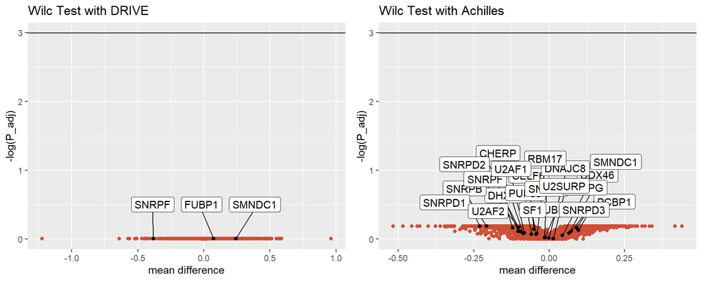

```r
plot.wilc.DRIVE.gene2 <- create_volcano_plot(test.results.gene2,"DRIVE","wilc",
                                       target.genes, show_sign_line=T)

plot.wilc.Achilles.gene2 <- create_volcano_plot(test.results.gene2,"Achilles",
                                                "wilc",target.genes)

grid.arrange(plot.wilc.DRIVE.gene2,plot.wilc.Achilles.gene2,ncol=2)
```

```r
rm(plot.wilc.DRIVE.gene2,plot.wilc.Achilles.gene2)
```

```r
significant.genes.table.DRIVE.gene2 <- create.significant.genes.table(
  test.results.gene2,"DRIVE","wilc")
significant.genes.table.Achilles.gene2 <- create.significant.genes.table(
  test.results.gene2,"Achilles","wilc")
significant.genes.table.DRIVE.gene2
```

```
## [1] gene    p_value p_adj   log
## <0 rows> (or 0-length row.names)
```

```r
significant.genes.table.Achilles.gene2
```

```
## [1] gene    p_value p_adj   log
## <0 rows> (or 0-length row.names)
```

```r
rm(significant.genes.table.DRIVE.gene2,significant.genes.table.Achilles.gene2)
```

## Bayes Test

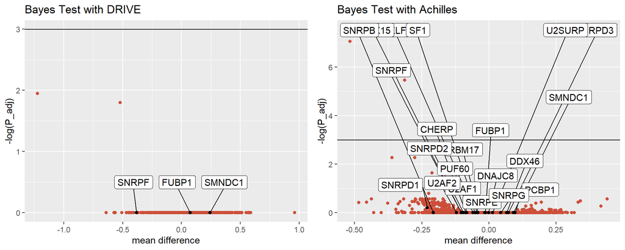

```r
plot.bayes.DRIVE.gene2 <- create_volcano_plot(test.results.gene2,"DRIVE","bayes",
                                       target.genes)

plot.bayes.Achilles.gene2 <- create_volcano_plot(test.results.gene2,"Achilles",
                                                "bayes",target.genes)

grid.arrange(plot.bayes.DRIVE.gene2,plot.bayes.Achilles.gene2,ncol=2)
```

```r
rm(plot.bayes.DRIVE.gene2,plot.bayes.Achilles.gene2)
```

```r
significant.genes.table.DRIVE.gene2 <- create.significant.genes.table(
  test.results.gene2,"DRIVE","bayes")
significant.genes.table.Achilles.gene2 <- create.significant.genes.table(
  test.results.gene2,"Achilles","bayes")
significant.genes.table.DRIVE.gene2
```

```
## [1] gene  p_adj log
## <0 rows> (or 0-length row.names)
```

```r
significant.genes.table.Achilles.gene2
```

```
##        gene        p_adj      log
## 16801   WRN 0.0008631782 7.054889
## 7530  KCNK5 0.0042544952 5.459779
```

```r
rm(significant.genes.table.DRIVE.gene2,significant.genes.table.Achilles.gene2,
   test.results.gene2)
```

# Data Analysis SNRPD1 and SNRPD2

We do the same for SNRPD1 and SNRPD2 combined.

## Mean Differences

```r
test.results.gene12 <- calc.mean.diffs.and.p.values(dep.scores.DRIVE,
                                           dep.scores.Achilles,
                                           class.table.comb.DRIVE,
                                           class.table.comb.Achilles)
```

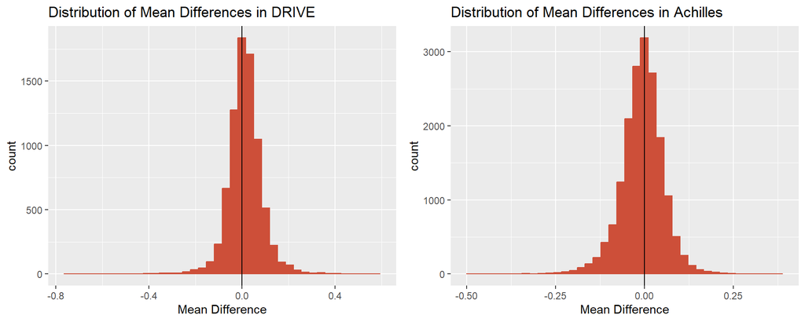

```r
plots <- plot.mean.diffs(test.results.gene12)
grid.arrange(plots$DRIVE,plots$Achilles,ncol=2)
```

```r
rm(class.table.comb.DRIVE,class.table.comb.Achilles,plots)
```

## Welch Test

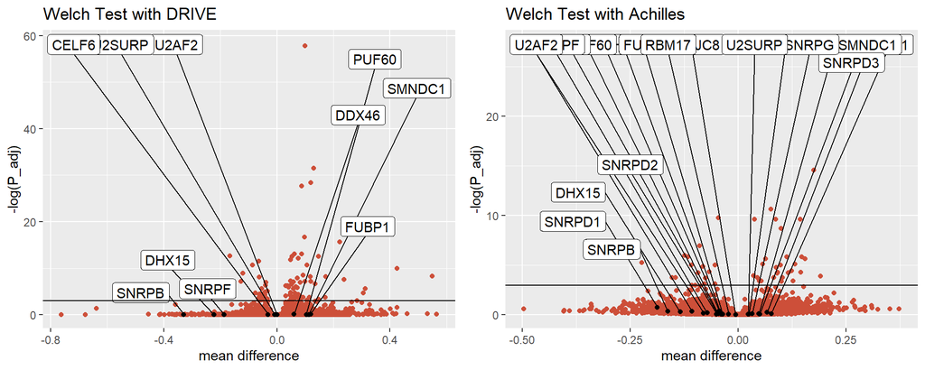

```r
plot.welch.DRIVE.gene12 <- create_volcano_plot(test.results.gene12,"DRIVE",
                                              "welch",target.genes)

plot.welch.Achilles.gene12 <- create_volcano_plot(test.results.gene12,"Achilles",
                                                "welch",target.genes)

grid.arrange(plot.welch.DRIVE.gene12,plot.welch.Achilles.gene12,ncol=2)
```

```r
rm(plot.welch.DRIVE.gene12,plot.welch.Achilles.gene12)
```

```r
significant.genes.table.DRIVE.gene12 <- create.significant.genes.table(
  test.results.gene12,"DRIVE","welch")
significant.genes.table.Achilles.gene12 <- create.significant.genes.table(
  test.results.gene12,"Achilles","welch")
significant.genes.table.DRIVE.gene12
```

```
##                                                    gene      p_value
## 5062                                              OGDHL 9.665238e-30
## 6495                                             ZBTB14 5.096266e-18
## 2629                                              KCNV1 1.730600e-16
## 7092                                              CUL4A 4.671732e-16
## 4005                                            H3F3AP4 3.418475e-11
## 2225                                               BRD4 1.142107e-10
## 3829                                                LYZ 2.054147e-09
## 5927                                              AGXT2 2.067768e-09
## 7422                                              AP1G2 3.679321e-09
## 3378                                              IGF1R 4.829545e-09
## 6961                                             TFAP2D 4.470846e-09
## 2448                                              USP49 7.891563e-09
## 259                                                GPHN 1.147841e-08
## 2361                                               MCM9 1.802939e-08
```

[output cut: 159 more lines]

```r
significant.genes.table.Achilles.gene12
```

```
##           gene      p_value        p_adj       log
## 605    ANGPTL2 1.227320e-16 2.164255e-12 26.858945
## 16342     UFL1 5.260846e-11 4.638488e-07 14.583707
## 745      AP4E1 3.951871e-09 2.322909e-05 10.670105
## 13130    RXFP2 1.308047e-08 5.766527e-05  9.760856
## 13072 RSPH10B2 1.826017e-08 6.439998e-05  9.650397
## 8222    LIMCH1 2.461278e-08 6.545325e-05  9.634174
## 13491   SETD1B 2.598235e-08 6.545325e-05  9.634174
## 13861  SLC27A2 7.615224e-08 1.678586e-04  8.692389
## 14263    SNX30 4.749484e-07 9.305821e-04  6.979700
## 8009    KRTDAP 1.403038e-06 2.474118e-03  6.001871
## 1868  C22orf39 1.895721e-06 2.933698e-03  5.831492
## 16237     UBA5 2.162758e-06 2.933698e-03  5.831492
## 17355   ZNF551 2.154380e-06 2.933698e-03  5.831492
## 514      ALG12 2.936917e-06 3.452640e-03  5.668616
```

[output cut: 30 more lines]

```r
rm(significant.genes.table.DRIVE.gene12,significant.genes.table.Achilles.gene12)
```

## Wilcoxon Test

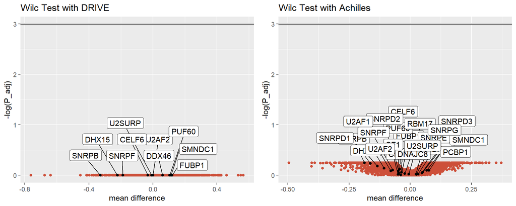

```r
plot.wilc.DRIVE.gene12 <- create_volcano_plot(test.results.gene12,"DRIVE","wilc",
                                       target.genes, show_sign_line=T)

plot.wilc.Achilles.gene12 <- create_volcano_plot(test.results.gene12,"Achilles",
                                                "wilc",target.genes)

grid.arrange(plot.wilc.DRIVE.gene12,plot.wilc.Achilles.gene12,ncol=2)
```

```r
rm(plot.wilc.DRIVE.gene12,plot.wilc.Achilles.gene12)
```

```r
significant.genes.table.DRIVE.gene12 <- create.significant.genes.table(
  test.results.gene12,"DRIVE","wilc")
significant.genes.table.Achilles.gene12 <- create.significant.genes.table(
  test.results.gene12,"Achilles","wilc")
significant.genes.table.DRIVE.gene12
```

```
## [1] gene    p_value p_adj   log
## <0 rows> (or 0-length row.names)
```

```r
significant.genes.table.Achilles.gene12
```

```
## [1] gene    p_value p_adj   log
## <0 rows> (or 0-length row.names)
```

```r
rm(significant.genes.table.DRIVE.gene12,significant.genes.table.Achilles.gene12)
```

## Bayes Test

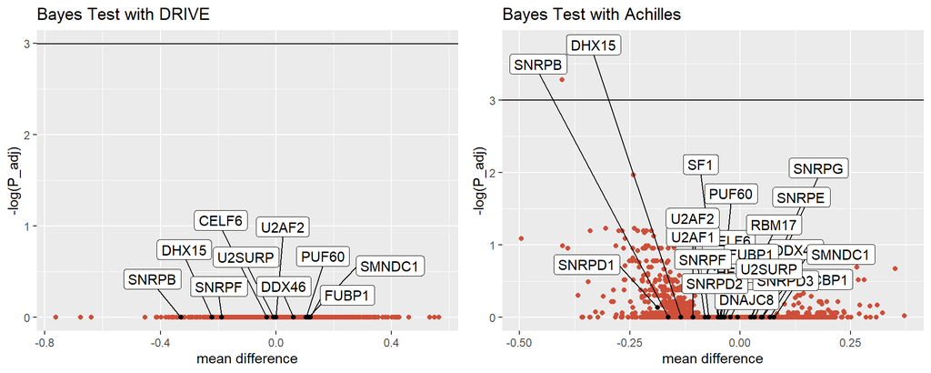

```r
plot.bayes.DRIVE.gene12 <- create_volcano_plot(test.results.gene12,"DRIVE",
                                               "bayes",target.genes)

plot.bayes.Achilles.gene12 <- create_volcano_plot(test.results.gene12,
                                                  "Achilles","bayes",
                                                  target.genes)

grid.arrange(plot.bayes.DRIVE.gene12,plot.bayes.Achilles.gene12,ncol=2)
```

```r
rm(plot.bayes.DRIVE.gene12,plot.bayes.Achilles.gene12)
```

```r
significant.genes.table.DRIVE.gene12 <- create.significant.genes.table(
  test.results.gene12,"DRIVE","bayes")
significant.genes.table.Achilles.gene12 <- create.significant.genes.table(
  test.results.gene12,"Achilles","bayes")
significant.genes.table.DRIVE.gene12
```

```
## [1] gene  p_adj log
## <0 rows> (or 0-length row.names)
```

```r
significant.genes.table.Achilles.gene12
```

```
##       gene      p_adj      log
## 16801  WRN 0.03778381 3.275875
```

```r
rm(significant.genes.table.DRIVE.gene12,significant.genes.table.Achilles.gene12,
   test.results.gene12)
```